# Detailed Insights: El Salvador

## Welcome!

You have reached the CCN Inventory Tool Detailed Insights Report.

Congratulations! This geography has available data.

Potential data availability within the Inventory Tool ranges from Tier I, Tier II, or Tier III Carbon stock estimates.

This document includes country-specific insights and more detailed analysis, including carbon stocks, emissions factors, and ecosystem wetland area for mangrove, marsh, and seagrass habitats. This report details information for the selected geography, **El Salvador**.

Explore the rest of the dashboard for more exciting visualizations, map features and data.

Resources referenced to calculate estimates for **El Salvador** are listed below under ‘References’ at the end of this document.

If you have any questions or data you would like to add to the Coastal Carbon Network, please reach out to us at CoastalCarbon@si.edu.

## Total Carbon Stock Estimates

Total Carbon stock estimates were calculated for each geography in total, and for mangrove, tidal marsh, and seagrass habitats when available.

We estimate that **El Salvador** contains a mean estimate of 9.42837^{6} metric tonnes soil Carbon.

We estimate that **El Salvador** contains between 1.14646^{7} to 7.39218^{6} metric tonnes of soil C to a depth of 1 m, with a mean estimate of 9.42837^{6} metric tonnes C.

Total Geography Level Carbon Stocks

[output not shown]

This total estimate includes total mangrove soil carbon stocks, with a mean estimate of 9.32758^{6} metric tonnes of soil C to a depth of 1 meter.

## Wetland Areas and Activities

We estimate mangrove area in **El Salvador** to be 2.95^{4} to 3.895^{4} hectares, with a mean estimate of 3.359^{4} hectares according to Global Mangrove Watch Bunting et al. (2018).

## Calculated Stocks and Emissions Factors

This section of the report details whether data is available to estimate Tier I, Tier II, or Tier III value estimates for tidal marsh, mangrove, and seagrass ecosystems in **El Salvador**.

If data for the selected country is available in the Coastal Carbon Atlas, we have applied a Tier II emission factor based on a simple average of country specific data queried from the Atlas.

Data from **El Salvador** included in the Coastal Carbon Atlas consists of 37 soil profiles from 31 watersheds. This data comes from 1 distinct habitat type(s).

In the case that there is not yet any country specific information in the Coastal Carbon Atlas, we instead applied IPCC Tier I estimate. IPCC Tier I estimates for mangrove, marsh, and seagrass ecosystems are listed below.

The table in this section also details whether the calculated Tier II value is significantly different from the estimated Tier I values. This is observed in the “Overlap” column.

IPCC Tier I Value Estimates

| Habitat | Mean | Lower_CI | Upper_CI |
| --- | --- | --- | --- |
| mangrove | 386 | 351 | 424 |
| marsh | 255 | 254 | 297 |
| seagrass | 108 | 84 | 139 |

## Data Availiability by Tier

Availiability of Tier I and Tier II Data

| Country | Territory | Habitat | Tier | Overlap |
| --- | --- | --- | --- | --- |
| El Salvador | El Salvador | mangrove | Tier II | Country-specific average is significantly less than Tier I |
| El Salvador | El Salvador | marsh | Tier I | No Tier II data available at this time |
| El Salvador | El Salvador | seagrass | Tier I | No Tier II data available at this time |

### Tier I Carbon Stocks

This section includes Tier I Carbon Stocks included for **El Salvador**. In the case that all habitats; mangrove, tidal marsh, and seagrass have availiable Tier II estimates, please refer to Table 2: IPCC Tier I Value Estimates for applicable Tier I values.

Tier I Carbon Stock Estimates

| Country | Territory | Habitat | Mean Stock (MgHa) | Lower CI | Upper CI |
| --- | --- | --- | --- | --- | --- |
| El Salvador | El Salvador | marsh | 255 | 254 | 297 |
| El Salvador | El Salvador | seagrass | 108 | 84 | 139 |

### Tier II Carbon Stocks

This table includes Tier II Carbon Stock estimates for **El Salvador**. Estimates in this table were derived from data queried from the Coastal Carbon Atlas.

A selected country may have available Tier II values for one or multiple habitats, this is dependent on core data accessible through the Coastal Carbon Atlas. At the time of analysis, referencing Version 1.5.0, **El Salvador** represents a total of 37 cores across 1 distinct habitats.

Tier II Carbon Stock Estimates

| Country | Territory | Habitat | Mean Stock (MgHa) | Lower CI | Upper CI | Standard Error |
| --- | --- | --- | --- | --- | --- | --- |
| El Salvador | El Salvador | mangrove | 278 | 231 | 325 | 23.94527 |

### Tier III Carbon Stocks

If there are no Tier III estimates associated with the selected country and specific habitat of interest, please refer to above Tier I and Tier II tables.

Tier III Carbon Stock Estimates

| Country | Territory | Habitat | Mean Stock (MgHa) | Lower CI | Upper CI |
| --- | --- | --- | --- | --- | --- |
| El Salvador | El Salvador | mangrove | 305 | 192 | 419 |

In the selected geography, El Salvador ,Tier III estimated stock MgHa values are greater than Tier II values estimated from Coastal Carbon Atlas Data. In this case, the Tier III Remote-sensing esimate overlaps country-specific average. Additionally, estimated Tier III stock values derived from remote sensing are less than estimates Tier I values. In this case, the Tier III Remote-sensing esimate overlaps Tier I estimate.

## Visualizations

### 1. Data Metrics

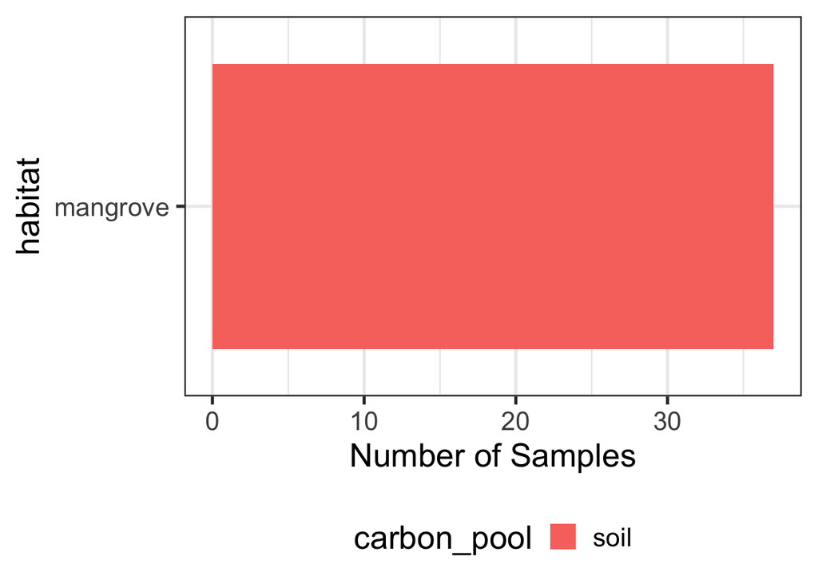

### 2. Emissions Factors

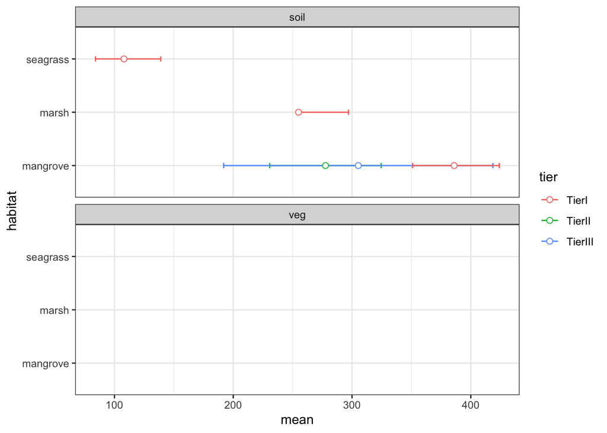

### 3. Activity Data

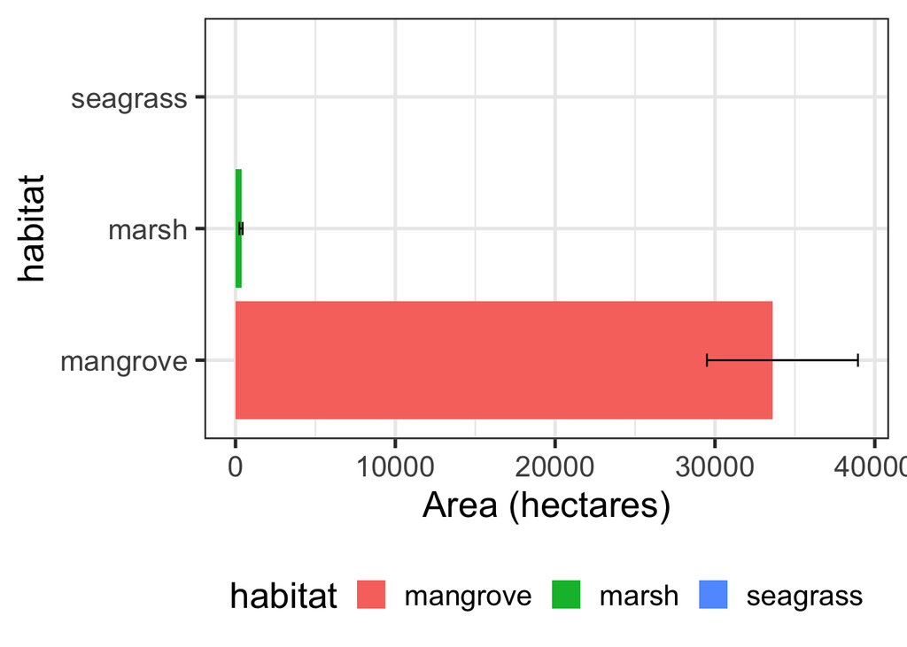

## References

Bunting, Pete, Ake Rosenqvist, Richard M. Lucas, Lisa-Maria Rebelo, Lammert Hilarides, Nathan Thomas, Andy Hardy, Takuya Itoh, Masanobu Shimada, and C. Max Finlayson. 2018. “The Global Mangrove Watch—a New 2010 Global Baseline of Mangrove Extent.” *Remote Sensing* 10 (10): 1669. https://doi.org/10.3390/rs10101669.

Rovai, Andr’e S., Robert R. Twilley, Edward Castañeda-Moya, Pablo Riul, Miguel Cifuentes-Jara, Marilyn Manrow-Villalobos, Paulo A. Horta, Jos’e C. Simonassi, and Alessandra L. Fonseca & Paulo R. Pagliosa. 2018. “Global Controls on Carbon Storage in Mangrove Soils.” *Nature Climate Change*. https://doi.org/https://doi.org/10.1038/s41558-018-0162-5.

Rovai, Andre, Robert Twilley, Edward Castaneda-Moya, Pablo Riul, Miguel Cifuentes-Jara, Marilyn Manrow-Villalobos, Paulo A. Horta, et al. 2022. “Dataset: Global Controls on Carbon Storage in Mangrove Soils.” https://doi.org/https://doi.org/10.25573/serc.21295713.v1.

Sanderman, Jonathan. 2017. “Global Mangrove Soil Carbon: Dataset and Spatial Maps.” Harvard Dataverse. https://doi.org/10.7910/dvn/ocyuit.

Worthington, Thomas A., Mark Spalding, Emily Landis, Tania L. Maxwell, Alejandro Navarro, Lindsey S. Smart, and Nicholas J. Murray. 2024. “The Distribution of Global Tidal Marshes from Earth Observation Data.” *Global Ecology and Biogeography* 33 (8). https://doi.org/10.1111/geb.13852.